# RReproducible Research: Peer Assessment 1

Reproducible Research Peer Assignment #1

## Loading and preprocessing the data

Load the data and Transform the date field

```r
#Load the libraries and read the data

library(ggplot2)
library(stats)
library(lattice)
rrData<- read.table("activity.csv", header=TRUE, sep=",")
rrData$date <- as.Date(rrData$date)
```

Histogram of the total steps per day

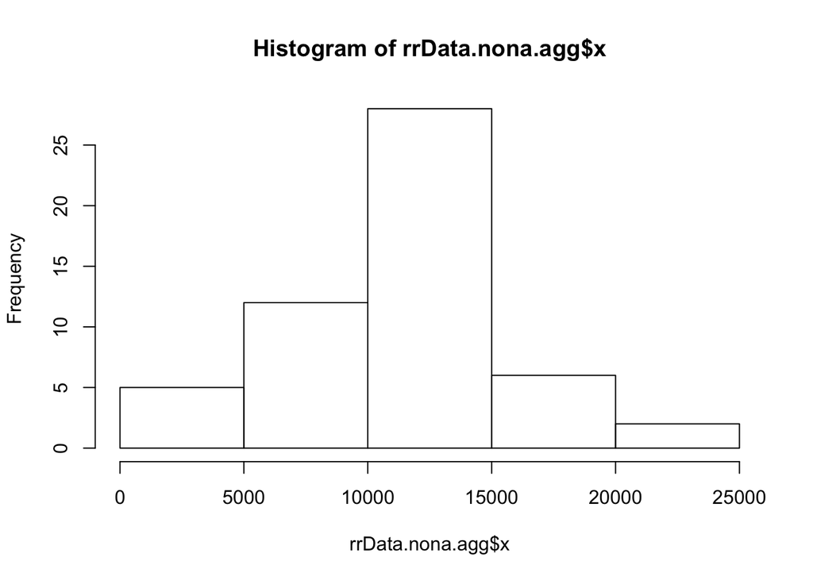

```r
rrData.nona<-na.exclude(rrData)
rrData.nona.agg<- aggregate(x = rrData.nona$steps, by = list(rrData.nona$date), FUN = sum)
hist(rrData.nona.agg$x)
```

## What is mean total number of steps taken per day?

The mean steps per day:

```r
mean(rrData.nona.agg$x)
```

```
## [1] 10766.19
```

The median steps taken per day

```r
median(rrData.nona.agg$x)
```

```
## [1] 10765
```

## What is the average daily activity pattern?

Describe the Average Daily Activity Pattern

```r
#Calculate the total number of steps each day
rrDataBy<- aggregate(x = rrData$steps, by = list(interval=rrData$interval), FUN=mean, na.rm=TRUE)
```

Time Series Plot of the 5 minute Interval

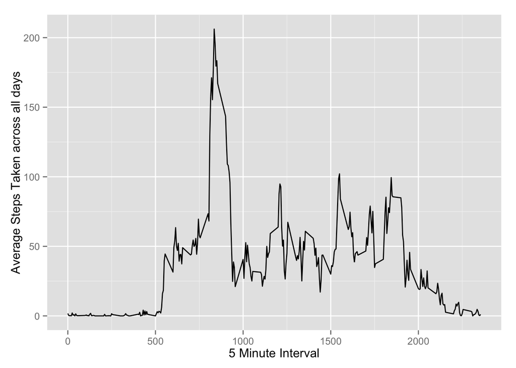

```r
ggplot(rrDataBy, aes(interval, x)) + geom_line() +
   xlab("5 Minute Interval") + ylab("Average Steps Taken across all days")
```

```r
max(rrDataBy$x)
```

```
## [1] 206.1698
```

```r
t<-which.max(rrDataBy$x)
max_v <- rrDataBy[t,1]
```

The 5 minute interval containing the maximum number of steps is:

```r
max_v
```

```
## [1] 835
```

```r
na_count <- sum(is.na(rrData$steps))
```

The total number of NA’s in the dataset:

```r
na_count
```

```
## [1] 2304
```